# Heart Disease Survival

## Age

The AGE variable details the age, in years, of the patient.

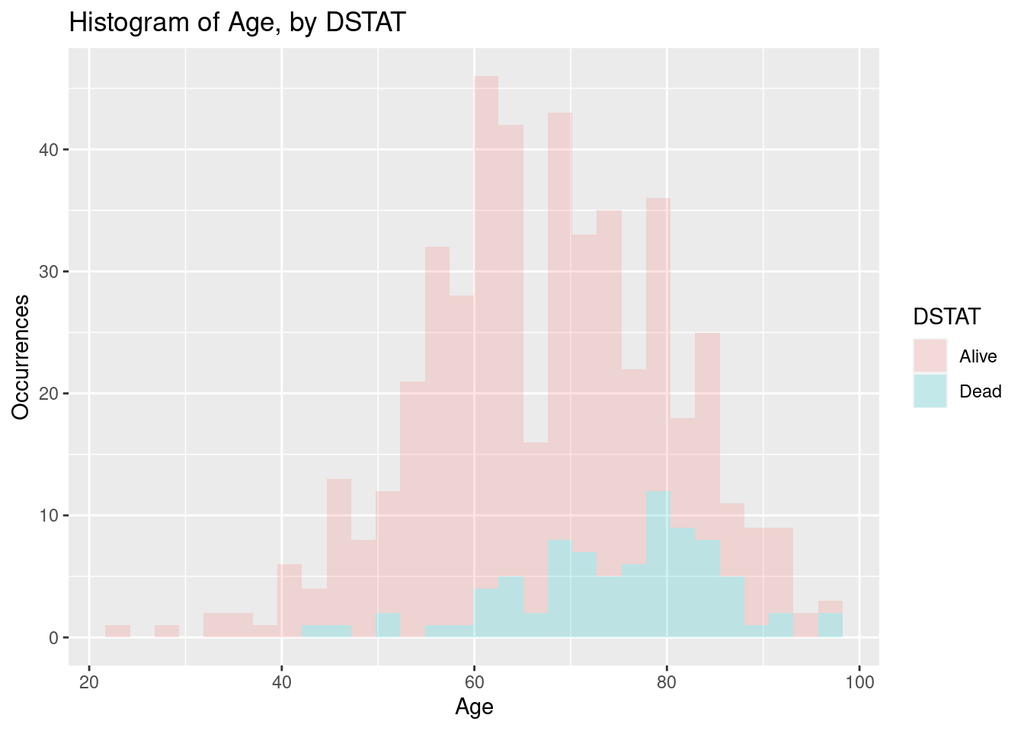

```r
summary(df$AGE)
##    Min. 1st Qu.  Median    Mean 3rd Qu.    Max.
##   24.00   59.00   68.00   67.48   77.00   98.00

generate_dstat_histogram(df, col = df$AGE, title = "Histogram of Age, by DSTAT", x = "Age")
## `stat_bin()` using `bins = 30`. Pick better value with `binwidth`.
```

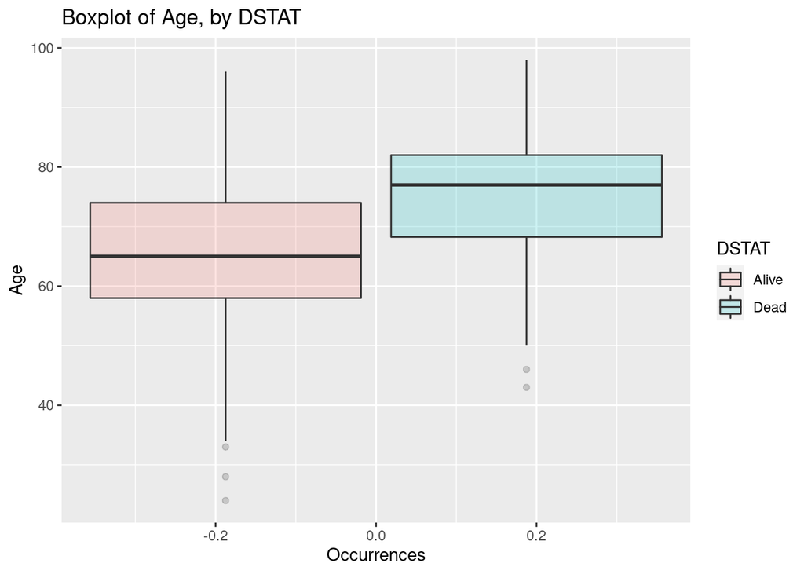

```r
generate_dstat_boxplot(df, col = df$AGE, title = "Boxplot of Age, by DSTAT", x = "Age")
```

The age variable was found to have 2 outliers, consisting of 24, 28

It appears that the `AGE` variable has Right skew when `DSTAT` is *alive* and a left skew when `DSTAT` is *dead*.

Additionally, the box plot shows that the inter quartile range (IQR) overlaps a bit when separated by `DSTAT`.

## Sex

The SEX variable details the sex of the patient during intake.

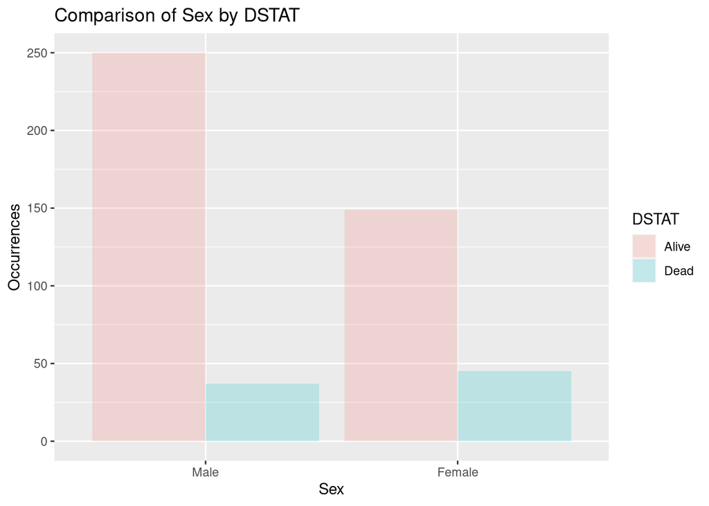

```r
df$SEX <- factor(df$SEX, labels = c("Male", "Female"))
print(table(df$SEX))
##
##   Male Female
##    287    194
generate_dstat_barchart_facet(df, col =  df$SEX, title = "Comparison of Sex by DSTAT", x = "Sex")
```

It is worth observing that 59.6673597 % of the observations in the data are male while, the remaining 40.3326403 % are female.

```r
alive <- df[df$DSTAT == 'Alive',]
dead <- df[df$DSTAT == 'Dead',]
dead_female <- sum(dead$SEX == 'Female')
total_female <- sum(df$SEX == 'Female')
dead_male <- sum(dead$SEX == 'Male')
total_male <- sum(df$SEX == 'Male')
```

Notably, there is an unbalanced ratio of male and female patients. It appears that 12.8919861 % of the males were deceased at discharge while 23.1958763 % of the females were deceased at discharge. Females were almost twice as likely to be deceased at discharge than males.

```r
test <- chisq.test(df$DSTAT, df$SEX)
print(test)
```

```
##
##  Pearson's Chi-squared test with Yates' continuity correction
##
## data:  df$DSTAT and df$SEX
## X-squared = 7.9771, df = 1, p-value = 0.004737
```

Given that the chi squared test had a p-value of 0.0047372 and using an alpha of 0.01, there appears to be **evidence** to refute the hypothesis that `DSTAT` and `SEX` are independent.

## CPK - Peak Cardiac Enzyme

The CPK variable details the peak cardiac enzyme.

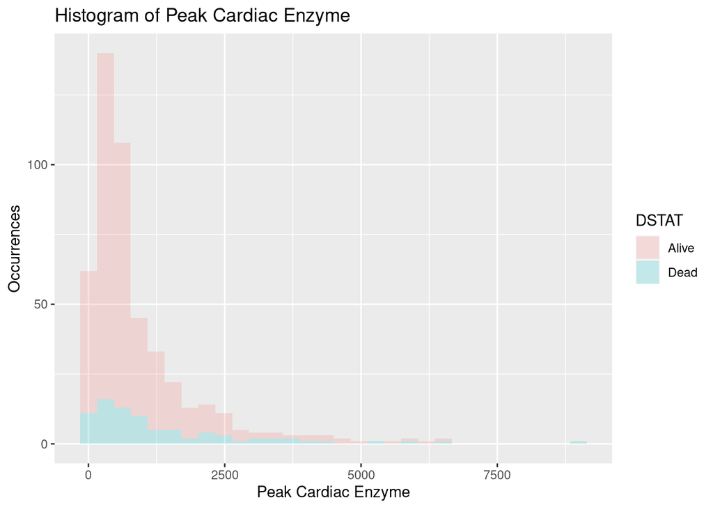

```r
summary(df$CPK)
##    Min. 1st Qu.  Median    Mean 3rd Qu.    Max.
##    10.0   270.0   587.0   941.5  1146.0  9000.0
generate_dstat_histogram(df, col = df$CPK, title = "Histogram of Peak Cardiac Enzyme", x = "Peak Cardiac Enzyme")
## `stat_bin()` using `bins = 30`. Pick better value with `binwidth`.
```

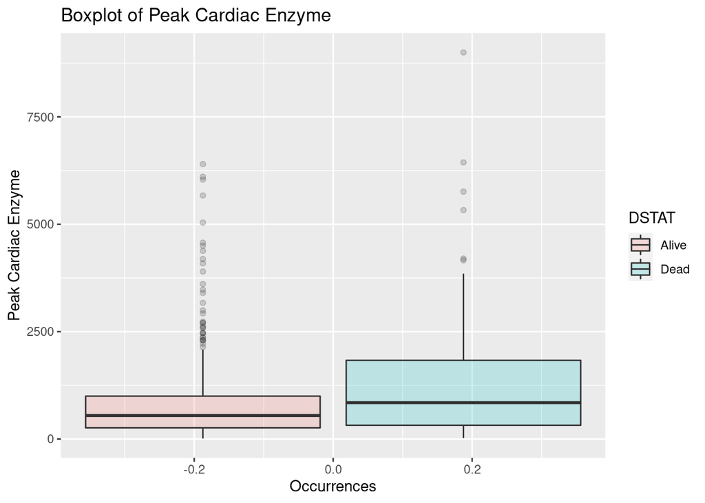

```r
generate_dstat_boxplot(df, col = df$CPK, title = "Boxplot of Peak Cardiac Enzyme", x = "Peak Cardiac Enzyme")
```

The CPK variable was found to have 12 outliers, consisting of 6040, 4381, 5330, 4570, 5040, 4501, 5670, 5760, 9000, 6440, 6105, 6400

From the histogram, its apparent that CPK has a strong right skew, regardless of whether `DSTAT`. Additionally, the boxplot shows that, when split by `DSTAT`, CPK with death has twice the IQR compared to CPK with alive patients.

## SHO - Cardiogenic Shock Complications

The SHO variable details the cardiogenic shock complications of the patient during intake.

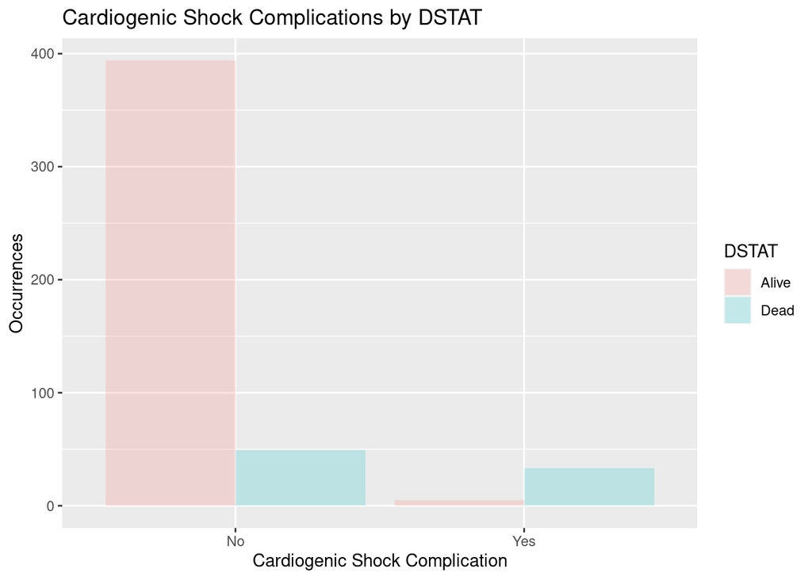

```r
df$SHO <- factor(df$SHO, labels = c("No", "Yes"))
print(table(df$SHO))
##
##  No Yes
## 443  38
generate_dstat_barchart_facet(df, col =  df$SHO, title = "Cardiogenic Shock Complications by DSTAT", x = "Cardiogenic Shock Complication")
```

It is worth observing that 7.9002079 % of the observations in the data are associated with cardiogenic shock while, the remaining 92.0997921 % is not.

```r
alive <- df[df$DSTAT == 'Alive',]
dead <- df[df$DSTAT == 'Dead',]
dead_no <- sum(dead$SHO == 'No')
total_no <- sum(df$SHO == 'No')
dead_yes <- sum(dead$SHO == 'Yes')
total_yes <- sum(df$SHO == 'Yes')
```

The cardiogenic shock variable was observed to be unbalanced and, upon initial inspection, it appears that having a cardiogenic shock complication makes a deceased discharge much more likely.

11.0609481 % of Non cardiogenic shock patients died, while 86.8421053 % of cardiogenic shock patients did die.

```r
test <- chisq.test(df$DSTAT, df$SHO)
print(test)
```

```
##
##  Pearson's Chi-squared test with Yates' continuity correction
##
## data:  df$DSTAT and df$SHO
## X-squared = 136.82, df = 1, p-value < 2.2e-16
```

Given that the chi squared test had a p-value of 1.3229446^{-31} and using an alpha of 0.01, there appears to be **evidence** to refute the hypothesis that `DSTAT` and `SHO` are independent, which is expected.

## CHF - Left Heart Failure Complications

The CHF variable details the left heart failure complications of the patient.

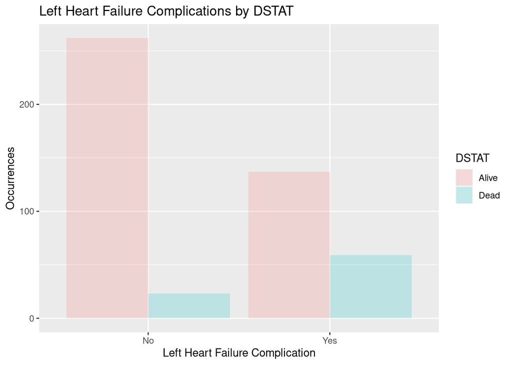

```r
df$CHF <- factor(df$CHF, labels = c("No", "Yes"))
print(table(df$CHF))
##
##  No Yes
## 285 196
generate_dstat_barchart_facet(df, col =  df$CHF, title = "Left Heart Failure Complications by DSTAT", x = "Left Heart Failure Complication")
```

It is worth observing that 40.7484407 % of the observations in the data are associated with left heart failure while, the remaining 59.2515593 % is not.

```r
alive <- df[df$DSTAT == 'Alive',]
dead <- df[df$DSTAT == 'Dead',]
dead_no <- sum(dead$CHF == 'No')
total_no <- sum(df$CHF == 'No')
dead_yes <- sum(dead$CHF == 'Yes')
total_yes <- sum(df$CHF == 'Yes')
```

8.0701754 % of the patients without left heart failure died, while 30.1020408 % of the patients with left heart failure did die.

```r
test <- chisq.test(df$DSTAT, df$CHF)
print(test)
```

```
##
##  Pearson's Chi-squared test with Yates' continuity correction
##
## data:  df$DSTAT and df$CHF
## X-squared = 38.32, df = 1, p-value = 6.006e-10
```

Given that the chi squared test had a p-value of 6.0058945^{-10} and using an alpha of 0.01, there appears to be **evidence** to refute the hypothesis that `DSTAT` and `CHF` are independent.

## MIORD - MI Order

The MIORD variable details whether the mycardial infarction is a first event or recurrent.

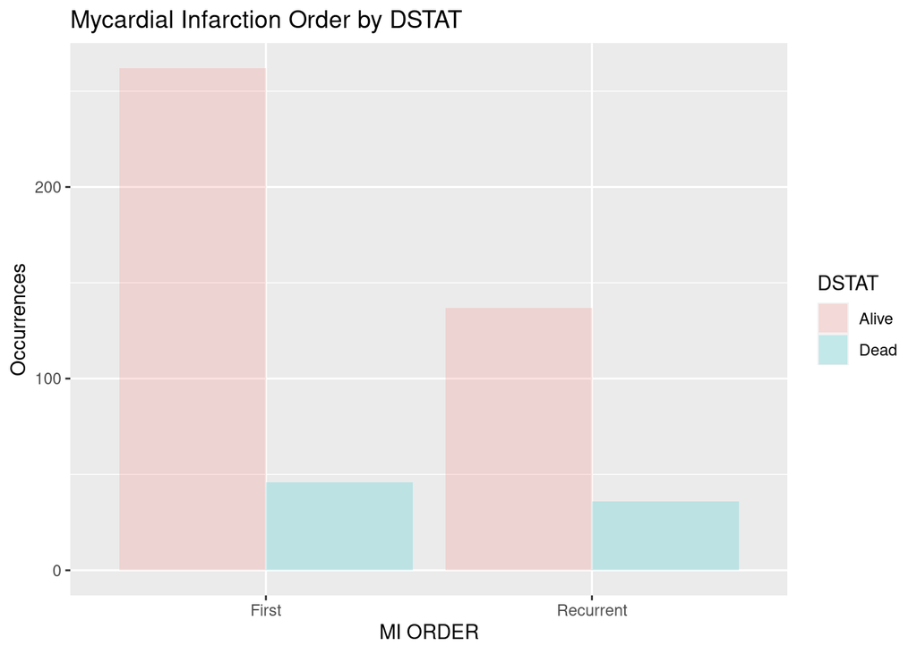

```r
df$MIORD <- factor(df$MIORD, labels = c("First", "Recurrent"))
print(table(df$MIORD))
##
##     First Recurrent
##       308       173
generate_dstat_barchart_facet(df, col =  df$MIORD, title = "Mycardial Infarction Order by DSTAT", x = "MI ORDER")
```

64.033264 % of the observations in the data are associated with a *first* mycardial infarction while, the remaining 35.966736 % have a recurrent mycardial infarction

```r
alive <- df[df$DSTAT == 'Alive',]
dead <- df[df$DSTAT == 'Dead',]
dead_rec <- sum(dead$MIORD == 'Recurrent')
total_rec <- sum(df$MIORD == 'Recurrent')
dead_first <- sum(dead$MIORD == 'First')
total_first <- sum(df$MIORD == 'First')
```

```r
test <- chisq.test(df$DSTAT, df$MIORD)
print(test)
```

```
##
##  Pearson's Chi-squared test with Yates' continuity correction
##
## data:  df$DSTAT and df$MIORD
## X-squared = 2.3036, df = 1, p-value = 0.1291
```

Given that the chi squared test had a p-value of 0.1290746 and using an alpha of 0.01, there appears to be a **lack of evidence** to refute the hypothesis that `DSTAT` and `MIORD` are independent. Due to this independence, the variable will be dropped.

```r
df$MIORD <- NULL
```

## MITYPE - MI Type

The MITYPE variable details whether the mycardial infraction is:

1. Q-Wave
2. Non Q-Wave
3. Indeterminate

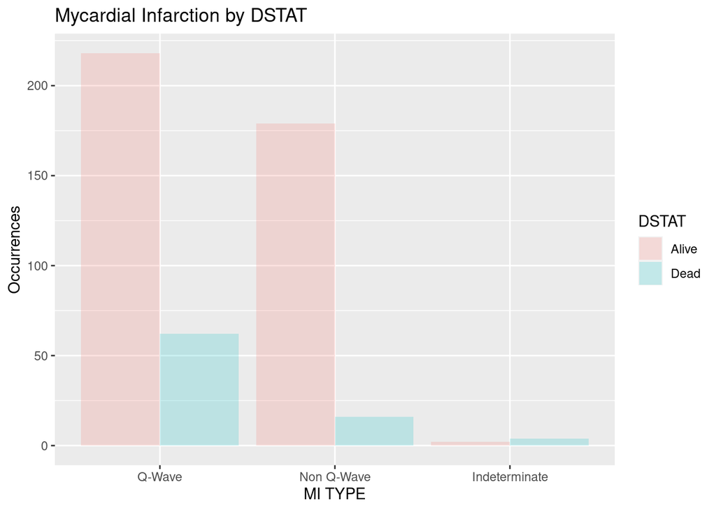

```r
df$MITYPE <- factor(df$MITYPE, labels = c("Q-Wave", "Non Q-Wave", "Indeterminate"))
print(table(df$MITYPE))
##
##        Q-Wave    Non Q-Wave Indeterminate
##           280           195             6
generate_dstat_barchart_facet(df, col =  df$MITYPE, title = "Mycardial Infarction by DSTAT", x = "MI TYPE")
```

The categories of the variable are not uniformly distributed in the data. The split of the categories is:

1. Q-wave - 58.2120582 %
2. Non Q-Wave - 40.5405405 %
3. Indeterminate - 1.2474012 %

```r
alive <- df[df$DSTAT == 'Alive',]
dead <- df[df$DSTAT == 'Dead',]
dead_q <- sum(dead$MITYPE == 'Q-Wave')
total_q <- sum(df$MITYPE == 'Q-Wave')
dead_nq <- sum(dead$MITYPE == 'Non Q-Wave')
total_nq <- sum(df$MITYPE == 'Non Q-Wave')
dead_ind <- sum(dead$MITYPE == 'Indeterminate')
total_ind <- sum(df$MITYPE == 'Indeterminate')
```

Next, looking at deceased discharge associations:

1. Q-Wave - **22.1428571** % of patients classified as Q-wave died.
2. Non Q-Wave - **8.2051282** % of patients classified as Non Q-wave died.
3. Indeterminate - **66.6666667** % of patients classified as Indeterminate died.

```r
test <- chisq.test(df$DSTAT, df$MITYPE)
print(test)
##
##  Pearson's Chi-squared test
##
## data:  df$DSTAT and df$MITYPE
## X-squared = 26.368, df = 2, p-value = 1.88e-06
```

Given that the chi squared test had a p-value of 1.8803937^{-6} and using an alpha of 0.01, there appears to be a **evidence** to refute the hypothesis that `DSTAT` and `MITYPE` are independent.

## Year

The year variable details the year the data was collected.

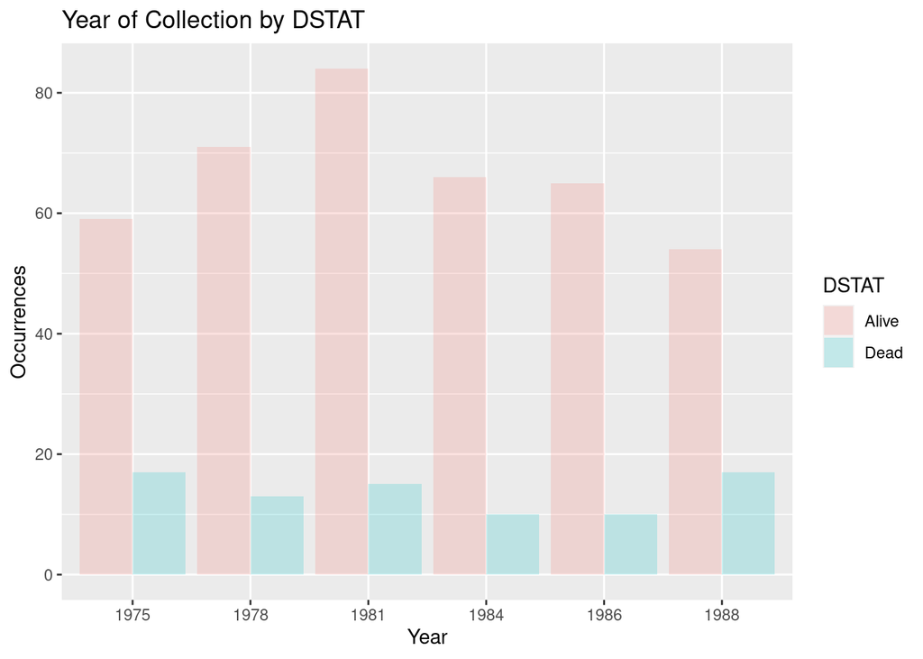

```r
df$YEAR <- factor(df$YEAR, labels = c("1975", "1978", "1981", "1984", "1986", "1988"))
print(table(df$YEAR))
##
## 1975 1978 1981 1984 1986 1988
##   76   84   99   76   75   71
generate_dstat_barchart_facet(df, col =  df$YEAR, title = "Year of Collection by DSTAT", x = "Year")
```

There does not appear to be a significant difference between the years. Additionally, since the year does not provide any new information, this variable will be removed.

```r
df$YEAR <- NULL
```

## YRGRP - Year Group

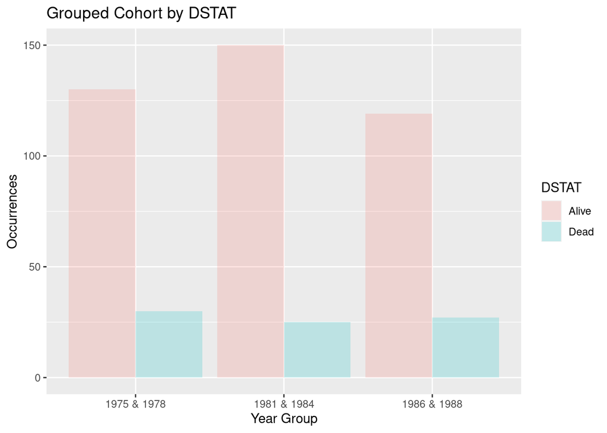

```r
df$YRGRP <- factor(df$YRGRP, labels = c("1975 & 1978", "1981 & 1984", "1986 & 1988"))
print(table(df$YRGRP))
##
## 1975 & 1978 1981 & 1984 1986 & 1988
##         160         175         146
generate_dstat_barchart_facet(df, col =  df$YRGRP, title = "Grouped Cohort by DSTAT", x = "Year Group")
```

There does not appear to be a significant difference between the years. Additionally, since the year does not provide any new information, this variable will be removed.

```r
df$YRGRP <- NULL
```

## LENSTAY - Length of Hospital Stay

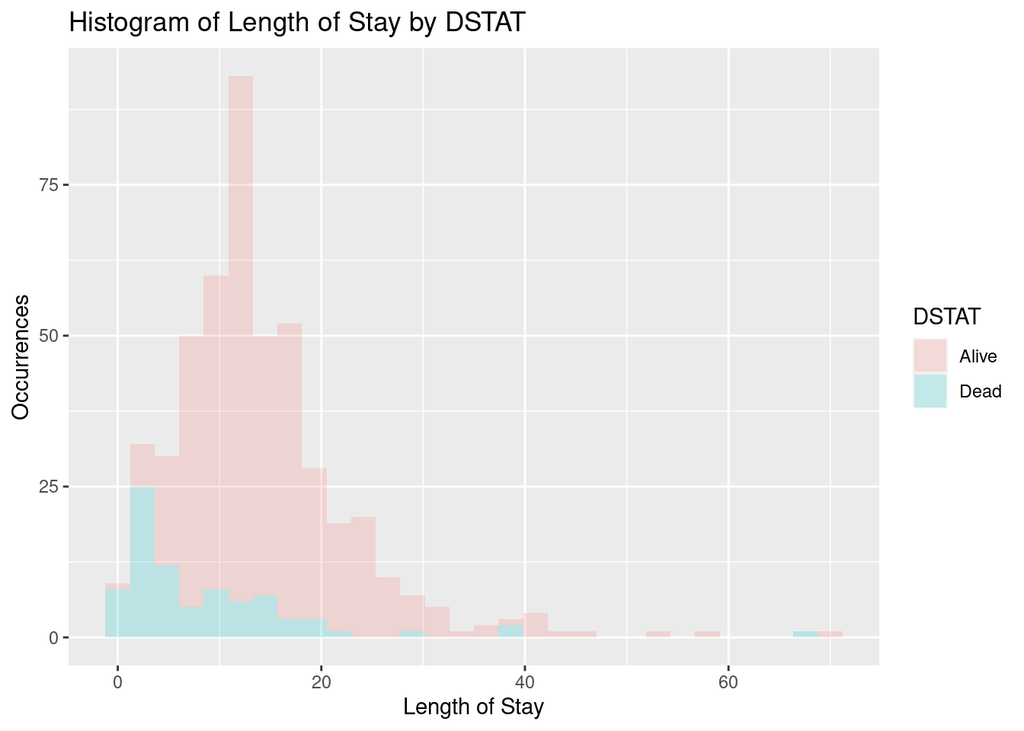

```r
summary(df$LENSTAY)
##    Min. 1st Qu.  Median    Mean 3rd Qu.    Max.
##    1.00    8.00   12.00   13.86   17.00   71.00
generate_dstat_histogram(df, col = df$LENSTAY, title = "Histogram of Length of Stay by DSTAT", x = "Length of Stay")
## `stat_bin()` using `bins = 30`. Pick better value with `binwidth`.
```

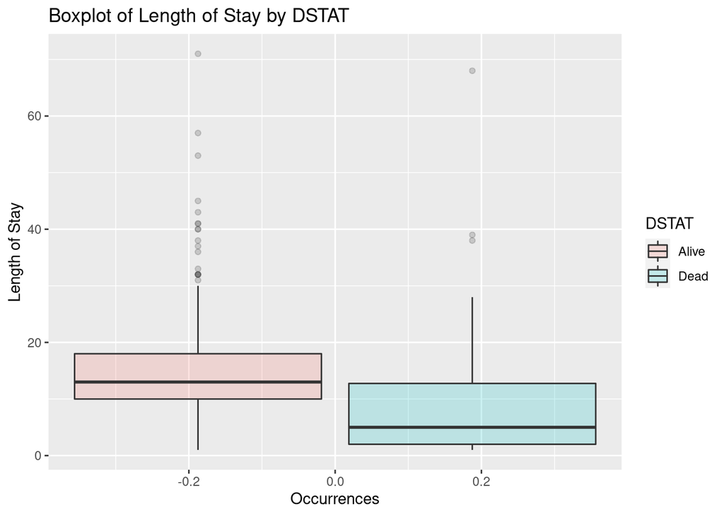

```r
generate_dstat_boxplot(df, col = df$LENSTAY, title = "Boxplot of Length of Stay by DSTAT", x = "Length of Stay")
```

It is both intuitive and counter-intuitive that deceased at discharge is associated with a shorter hospital stay. However, given that the objective is to create a model to find the probability of deceased at discharge during intake and not during the stay, this variable will be removed.

```r
df$LENSTAY <- NULL
```

## LENFOL - Length of Follow Up

The length of follow-up variable details the number of days before the next follow-up.

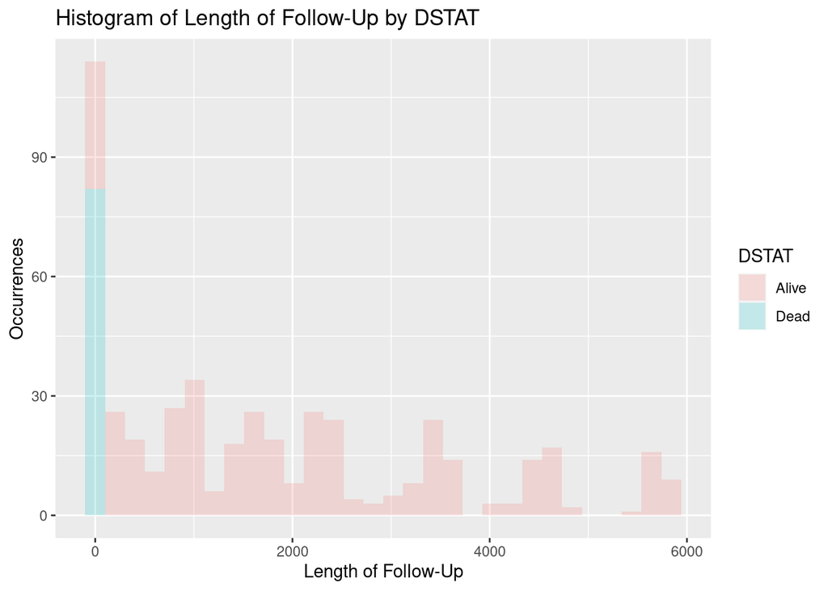

```r
summary(df$LENFOL)
##    Min. 1st Qu.  Median    Mean 3rd Qu.    Max.
##       1     150    1420    1735    2551    5843
generate_dstat_histogram(df, col = df$LENFOL, title = "Histogram of Length of Follow-Up by DSTAT", x = "Length of Follow-Up")
## `stat_bin()` using `bins = 30`. Pick better value with `binwidth`.
```

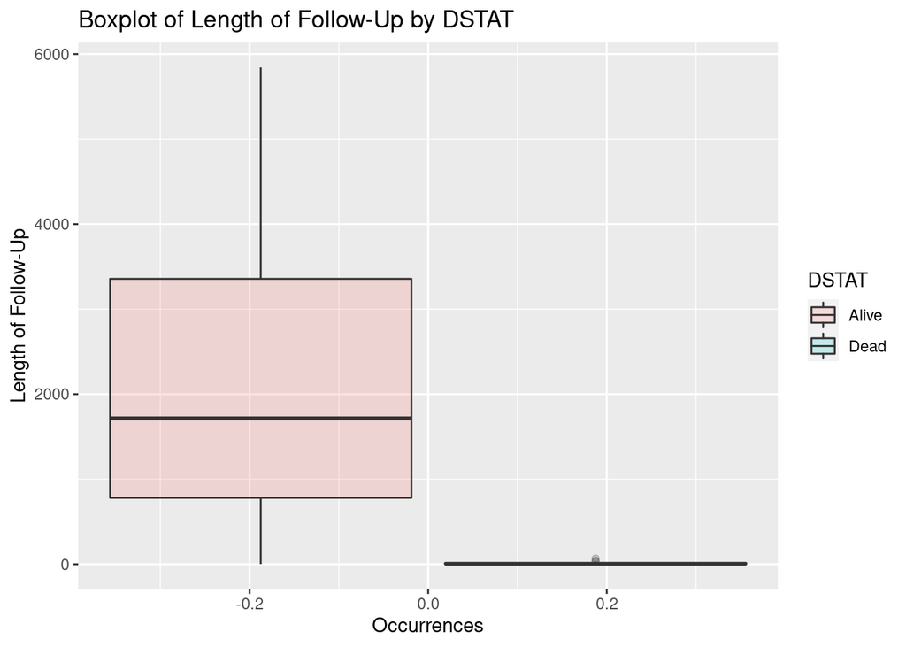

```r
generate_dstat_boxplot(df, col = df$LENFOL, title = "Boxplot of Length of Follow-Up by DSTAT", x = "Length of Follow-Up")
```

Given that this variable is post discharge, it is not useful for the objective and will be removed.

```r
df$LENFOL <- NULL
```

## FSTAT - Status at Follow Up

The FSTAT is the status at follow up and details whether the patient was dead or alive.

```r
df$FSTAT <- factor(df$FSTAT, labels = c("Alive", "Dead"))
table(df$FSTAT)
##
## Alive  Dead
##   232   249
```

Given that that follow-up is post discharge, this variable will be removed.

```r
df$FSTAT <- NULL
```

# Modeling

The variable remaining in the data consists of AGE, SEX, CPK, SHO, CHF, MITYPE, DSTAT. Two of these variables are quantitative in nature will need to be preprocessed for modeling.

## Train Test Split

```r
df <- read.csv("whas1.csv")
df$ID <- NULL
df$MIORD <- NULL
df$YRGRP <- NULL
df$YEAR <- NULL
df$LENSTAY <- NULL
df$LENFOL <- NULL
df$FSTAT <- NULL
data_partitioned <- initial_split(df, prop = 0.70, strata = DSTAT)
train <- training(data_partitioned)
test <-  testing(data_partitioned)
```

## Scaling

The `AGE` and the `CPK` variable both need to be scaled. However, to prevent the training set from affecting the test set, the two are scaled separately.

```r
train$AGE <- scale(train$AGE)
train$CPK <- scale(train$CPK)
test$AGE <- scale(test$AGE)
test$CPK <- scale(test$CPK)
```

## Model 1

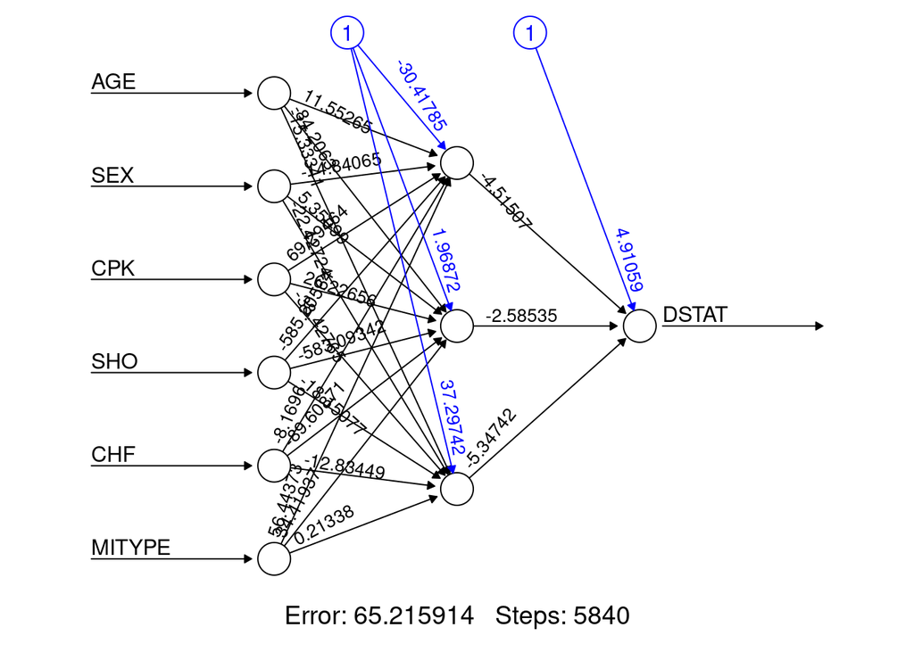

```r
model1 <- neuralnet(formula = DSTAT ~ ., data =train, hidden=3, err.fct="ce", linear.output = FALSE)
plot(model1, rep="best")
```

### Training Evaluation

```r
model1_predictions<-neuralnet::compute(model1, model1$covariate)$net.result
# round to the classes
model1_predictions<-apply(model1_predictions, c(1), round)
# Create the confusion matrix
x <- table(model1_predictions, train$DSTAT, dnn =c("Predicted", "Actual"))
TP <- tryCatch({ TP <- x[1,1]}, error=function(cond){return(0)})
TN <- tryCatch({ TN <- x[2,2]}, error=function(cond){return(0)})
FP <- tryCatch({ FP <- x[1,2]}, error=function(cond){return(0)})
FN <- tryCatch({ FN <- x[2,1]}, error=function(cond){return(0)})
```

|  | Train Alive | Train Dead |
| --- | --- | --- |
| **Classified Alive** | 268 | 21 |
| **Classified Dead** | 11 | 36 |

The first model achieved an accuracy of **90.4761905%** Against the training set. Additionally, the model exhibited a false positive rate of **36.8421053**%.

### Testing Evaluation

```r
model1_predictions<-neuralnet::compute(model1, test[, -7])$net.result
# round to the classes
model1_predictions<-apply(model1_predictions, c(1), round)
# Create the confusion matrix
x <- table(model1_predictions, test$DSTAT, dnn =c("Predicted", "Actual"))
TP <- tryCatch({ TP <- x[1,1]}, error=function(cond){return(0)})
TN <- tryCatch({ TN <- x[2,2]}, error=function(cond){return(0)})
FP <- tryCatch({ FP <- x[1,2]}, error=function(cond){return(0)})
FN <- tryCatch({ FN <- x[2,1]}, error=function(cond){return(0)})
```

|  | Test Alive | Test Dead |
| --- | --- | --- |
| **Classified Alive** | 108 | 11 |
| **Classified Dead** | 12 | 14 |

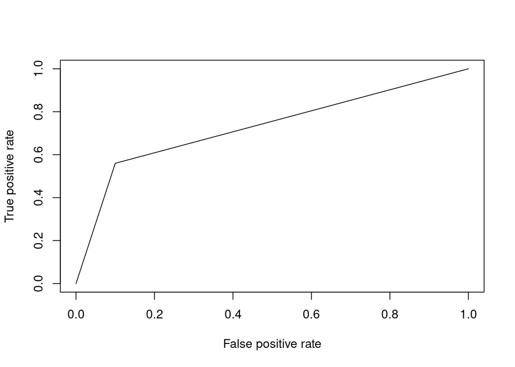

```r
predictions = prediction(model1_predictions, test$DSTAT)
plot(performance(predictions, "tpr", "fpr"))
```

## Model 2

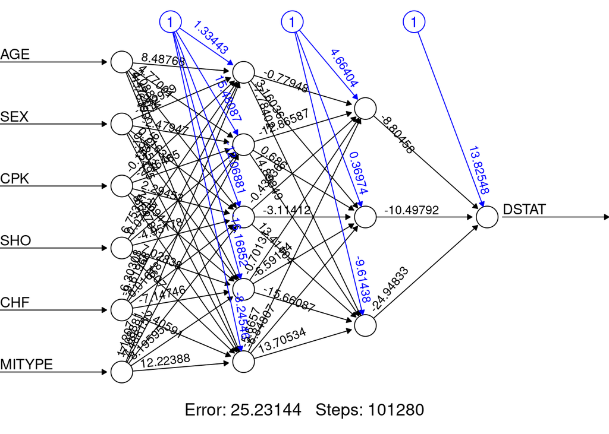

```r
model2 <-  neuralnet(formula = DSTAT ~ ., data =train, hidden=c(5,3), err.fct="ce", stepmax = 1e+06, learningrate = 0.001, algorithm = "backprop", linear.output = FALSE, rep = 10, threshold = 0.1)
plot(model2, rep="best")
```

### Training Evaluation

```r
model2_predictions<-neuralnet::compute(model2, model2$covariate)$net.result
# round to the classes
model2_predictions<-apply(model2_predictions, c(1), round)
# Create the confusion matrix
x <- table(model2_predictions, train$DSTAT, dnn =c("Predicted", "Actual"))
TP <- tryCatch({ TP <- x[1,1]}, error=function(cond){return(0)})
TN <- tryCatch({ TN <- x[2,2]}, error=function(cond){return(0)})
FP <- tryCatch({ FP <- x[1,2]}, error=function(cond){return(0)})
FN <- tryCatch({ FN <- x[2,1]}, error=function(cond){return(0)})
```

|  | Train Alive | Train Dead |
| --- | --- | --- |
| **Classified Alive** | 259 | 13 |
| **Classified Dead** | 20 | 44 |

The second model achieved an accuracy of **90.1785714%** Against the training set. Additionally, the model exhibited a false positive rate of **22.8070175**%.

### Testing Evaluation

```r
model2_predictions<-neuralnet::compute(model2, test[, -7])$net.result
# round to the classes
model2_predictions<-apply(model2_predictions, c(1), round)
# Create the confusion matrix
x <- table(model2_predictions, test$DSTAT, dnn =c("Predicted", "Actual"))
TP <- tryCatch({ TP <- x[1,1]}, error=function(cond){return(0)})
TN <- tryCatch({ TN <- x[2,2]}, error=function(cond){return(0)})
FP <- tryCatch({ FP <- x[1,2]}, error=function(cond){return(0)})
FN <- tryCatch({ FN <- x[2,1]}, error=function(cond){return(0)})
```

|  | Test Alive | Test Dead |
| --- | --- | --- |
| **Classified Alive** | 107 | 10 |
| **Classified Dead** | 13 | 15 |

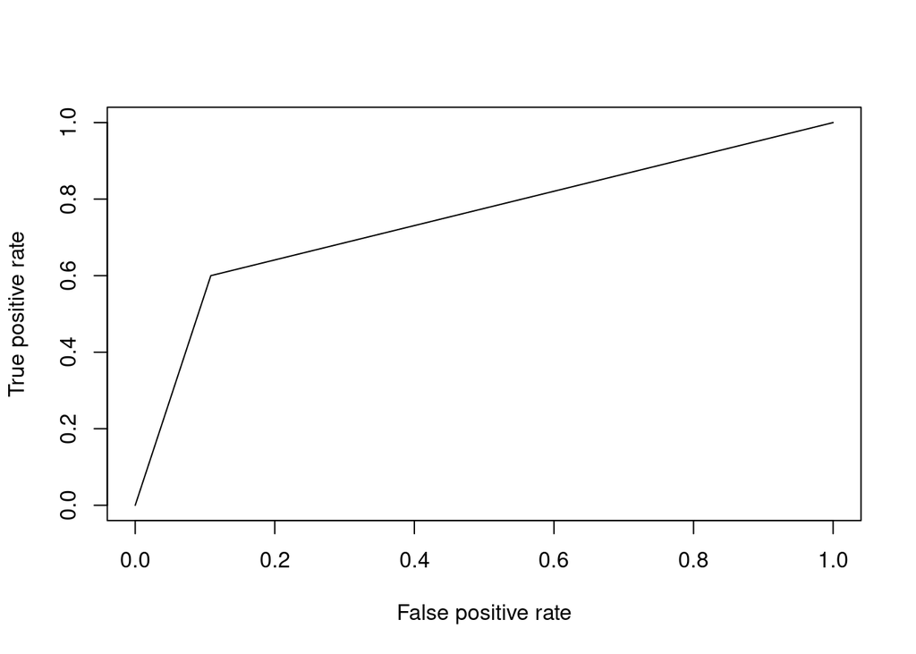

```r
predictions = prediction(model2_predictions, test$DSTAT)
plot(performance(predictions, "tpr", "fpr"))
```

## Model 3

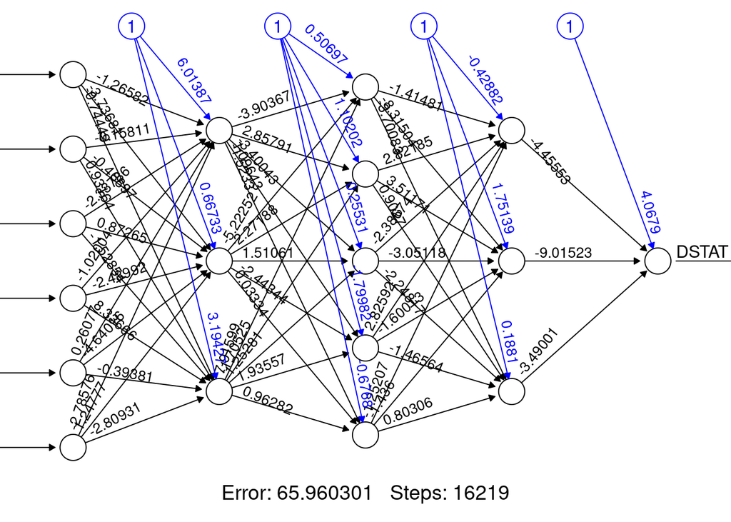

```r
model3 <-  neuralnet(formula = DSTAT ~ ., data =train, hidden=c(3,5,3), err.fct="ce", stepmax = 1e+06, learningrate = 0.001, algorithm = "backprop", linear.output = FALSE, rep = 10, threshold = 0.3)
plot(model3, rep="best")
```

### Training Evaluation

```r
model3_predictions<-neuralnet::compute(model3, model3$covariate)$net.result
# round to the classes
model3_predictions<-apply(model3_predictions, c(1), round)
# Create the confusion matrix
x <- table(model3_predictions, train$DSTAT, dnn =c("Predicted", "Actual"))
TP <- tryCatch({ TP <- x[1,1]}, error=function(cond){return(0)})
TN <- tryCatch({ TN <- x[2,2]}, error=function(cond){return(0)})
FP <- tryCatch({ FP <- x[1,2]}, error=function(cond){return(0)})
FN <- tryCatch({ FN <- x[2,1]}, error=function(cond){return(0)})
```

|  | Train Alive | Train Dead |
| --- | --- | --- |
| **Classified Alive** | 269 | 26 |
| **Classified Dead** | 10 | 31 |

The third model achieved an accuracy of **89.2857143%** Against the training set. Additionally, the model exhibited a false positive rate of **45.6140351**%.

### Testing Evaluation

```r
model3_predictions<-neuralnet::compute(model3, test[, -7])$net.result
# round to the classes
model3_predictions<-apply(model3_predictions, c(1), round)
# Create the confusion matrix
x <- table(model3_predictions, test$DSTAT, dnn =c("Predicted", "Actual"))
TP <- tryCatch({ TP <- x[1,1]}, error=function(cond){return(0)})
TN <- tryCatch({ TN <- x[2,2]}, error=function(cond){return(0)})
FP <- tryCatch({ FP <- x[1,2]}, error=function(cond){return(0)})
FN <- tryCatch({ FN <- x[2,1]}, error=function(cond){return(0)})
```

|  | Test Alive | Test Dead |
| --- | --- | --- |
| **Classified Alive** | 116 | 12 |
| **Classified Dead** | 4 | 13 |

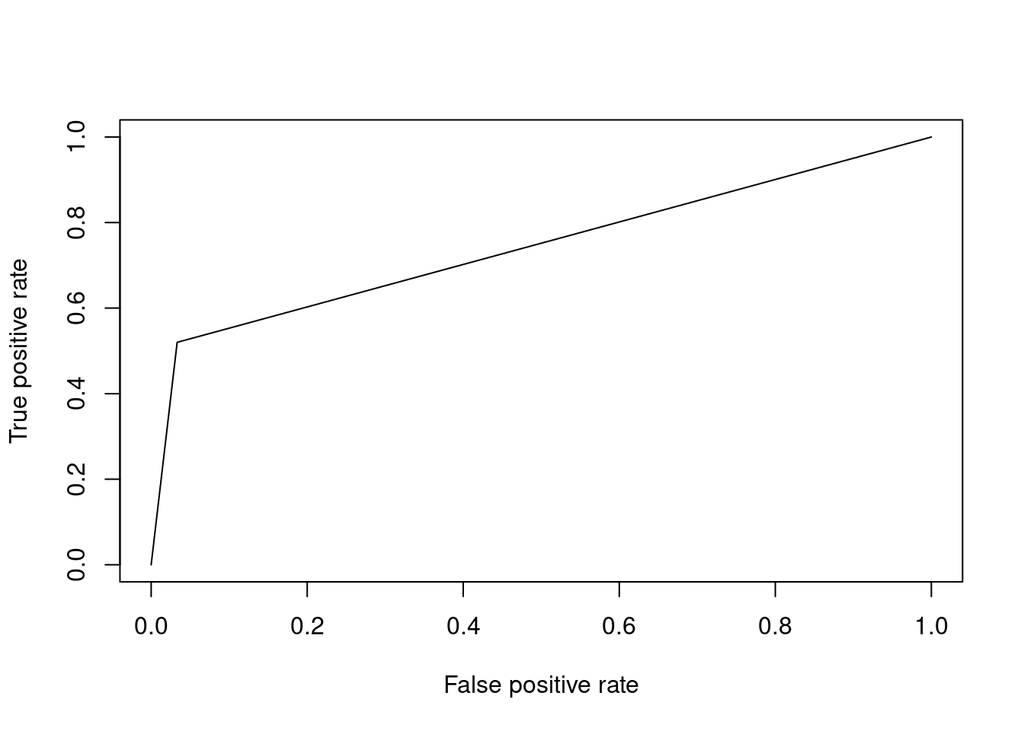

```r
predictions = prediction(model3_predictions, test$DSTAT)
plot(performance(predictions, "tpr", "fpr"))
```

# References

Hosmer D. W., & Lemeshow, S. (1998). *Heart Disease Survival*[CSV]. Retrieved from https://learn.umgc.edu/d2l/le/content/685926/viewContent/26235200/View